## Regression/Classification trees and Random Forests

## Ozone data set

```r
library(faraway)
data(ozone)
?ozone
summary(ozone)
```

```
##        O3              vh            wind           humidity
##  Min.   : 1.00   Min.   :5320   Min.   : 0.000   Min.   :19.00
##  1st Qu.: 5.00   1st Qu.:5690   1st Qu.: 3.000   1st Qu.:47.00
##  Median :10.00   Median :5760   Median : 5.000   Median :64.00
##  Mean   :11.78   Mean   :5750   Mean   : 4.848   Mean   :58.13
##  3rd Qu.:17.00   3rd Qu.:5830   3rd Qu.: 6.000   3rd Qu.:73.00
##  Max.   :38.00   Max.   :5950   Max.   :11.000   Max.   :93.00
##       temp            ibh              dpg              ibt
##  Min.   :25.00   Min.   : 111.0   Min.   :-69.00   Min.   :-25.0
##  1st Qu.:51.00   1st Qu.: 877.5   1st Qu.: -9.00   1st Qu.:107.0
##  Median :62.00   Median :2112.5   Median : 24.00   Median :167.5
##  Mean   :61.75   Mean   :2572.9   Mean   : 17.37   Mean   :161.2
##  3rd Qu.:72.00   3rd Qu.:5000.0   3rd Qu.: 44.75   3rd Qu.:214.0
##  Max.   :93.00   Max.   :5000.0   Max.   :107.00   Max.   :332.0
##       vis             doy
##  Min.   :  0.0   Min.   : 33.0
##  1st Qu.: 70.0   1st Qu.:120.2
##  Median :120.0   Median :205.5
##  Mean   :124.5   Mean   :209.4
##  3rd Qu.:150.0   3rd Qu.:301.8
##  Max.   :350.0   Max.   :390.0
```

```r
ozone[1:5,]
```

```
##   O3   vh wind humidity temp  ibh dpg ibt vis doy
## 1  3 5710    4       28   40 2693 -25  87 250  33
## 2  5 5700    3       37   45  590 -24 128 100  34
## 3  5 5760    3       51   54 1450  25 139  60  35
## 4  6 5720    4       69   35 1568  15 121  60  36
## 5  4 5790    6       19   45 2631 -33 123 100  37
```

### Show pair-wise correlations among the variables

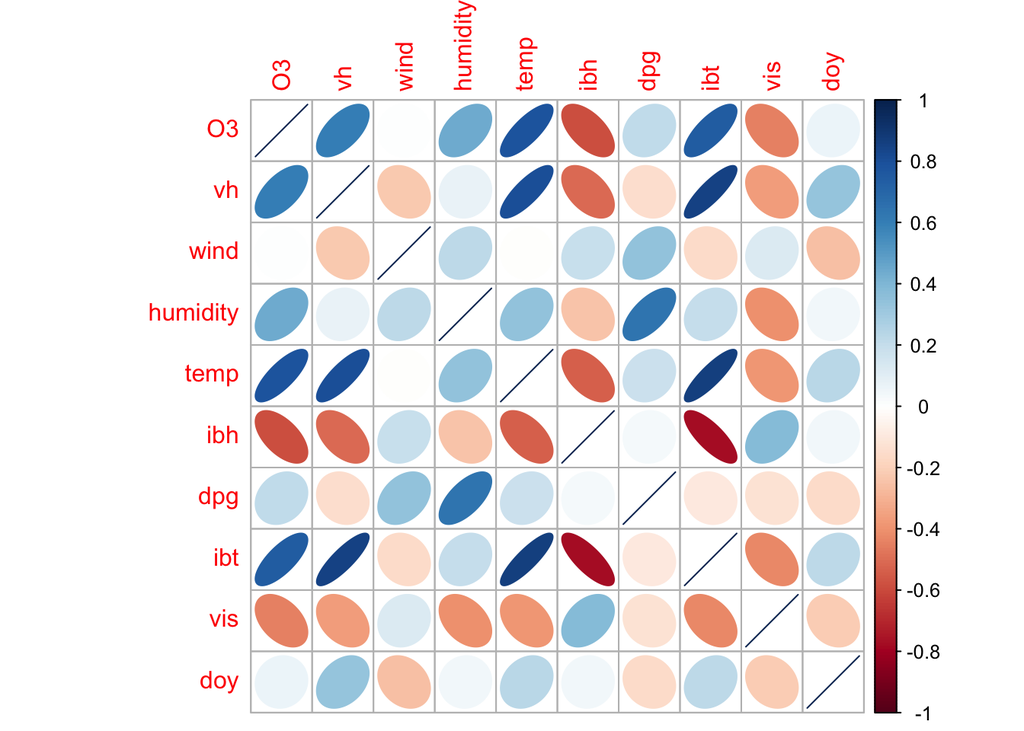

```r
library(corrplot)
M=cor(ozone)
corrplot(M, method="ellipse")
```

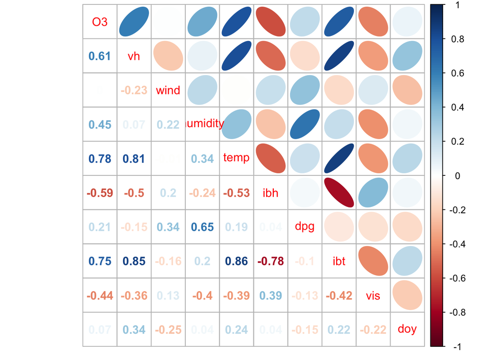

```r
corrplot.mixed(M, lower="number", upper="ellipse")
```

The goal is to predict `O3` with the other variables. The following pairwise plots reveal several nonlinear relationships indicating that a linear regression might not be appropriate without the addition of some transformations.

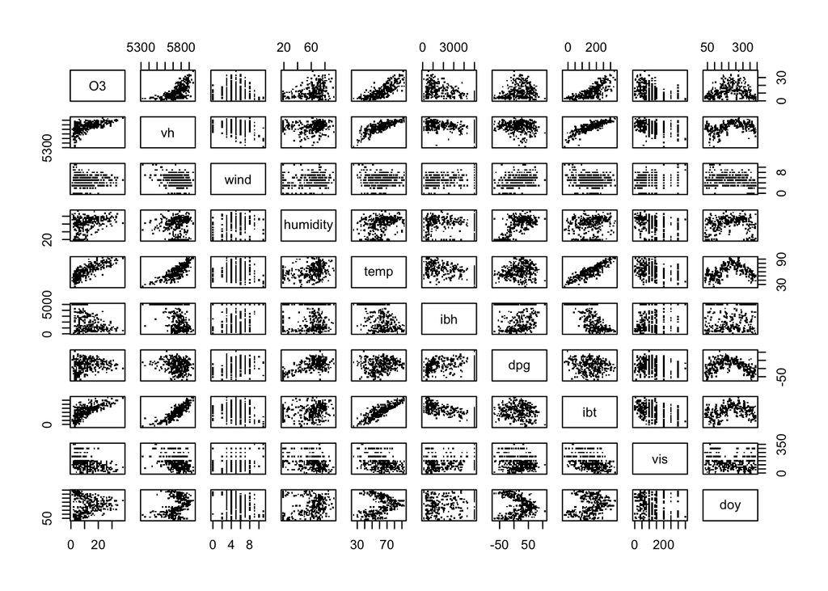

```r
pairs(ozone, pch=".")
```

### Fit a Regression tree using the library `rpart`

```r
library(rpart)
roz = rpart(O3 ~ .,ozone,cp=0.01)
roz
```

```
## n= 330
##
## node), split, n, deviance, yval
##       * denotes terminal node
##
##  1) root 330 21115.4100 11.775760
##    2) temp< 67.5 214  4114.3040  7.425234
##      4) ibh>=3573.5 108   689.6296  5.148148 *
##      5) ibh< 3573.5 106  2294.1230  9.745283
##       10) dpg< -9.5 35   362.6857  6.457143 *
##       11) dpg>=-9.5 71  1366.4790 11.366200
##         22) ibt< 159 40   287.9000  9.050000 *
##         23) ibt>=159 31   587.0968 14.354840 *
##    3) temp>=67.5 116  5478.4400 19.801720
##      6) ibt< 226.5 55  1276.8360 15.945450
##       12) humidity< 59.5 10   167.6000 10.800000 *
##       13) humidity>=59.5 45   785.6444 17.088890 *
##      7) ibt>=226.5 61  2646.2620 23.278690
##       14) doy>=306.5 8   398.0000 16.000000 *
##       15) doy< 306.5 53  1760.4530 24.377360
##         30) vis>=55 36  1149.8890 22.944440 *
##         31) vis< 55 17   380.1176 27.411760 *
```

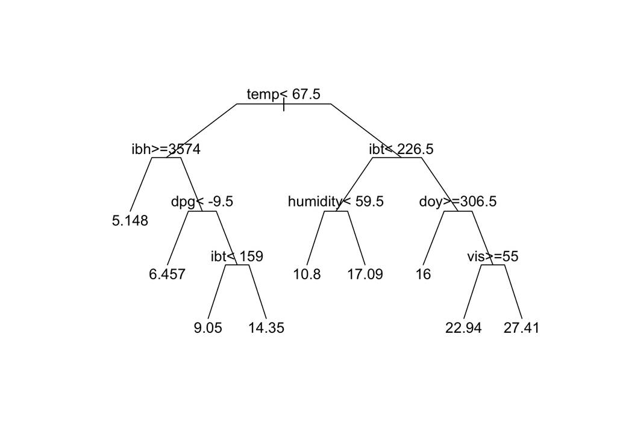

```r
plot(roz,compress=T,uniform=T,branch=0.4,margin=.10)
text(roz)
```

### Prediction with a tree model

Prediction for the median of predictors

```r
x0 = apply(ozone[,-1],2,median)
x0
```

```
##       vh     wind humidity     temp      ibh      dpg      ibt      vis
##   5760.0      5.0     64.0     62.0   2112.5     24.0    167.5    120.0
##      doy
##    205.5
```

```r
predict(roz, data.frame(t(x0)))
```

```
##        1
## 14.35484
```

## Tree pruning

### Which sub-tree should be selected?

This is essentially a model selection problem. Can we use criteria like AIC/BIC?

Indeed we could define a model selection criterion similar to AIC/BIC: RSS + alpha*tree-size. Here the tree-size is defined to be the number of parameters a tree may has, which is equal to the number of terminal (or leaves) nodes. The penalty per extra dimension, i.e., alpha, is also referred to as the complexity parameter (CP).

Instead of setting the CP to be 2 or log(n), try all possible values for CP.

It turns out when we increase CP from 0 to infinity, the resulting optimal sub-trees form a nested sequence, i.e., the optimal trees get smaller when it costs more to have an additional node.

The optimal subtree (based on the cost-complexity criterion) stays the same for a range of CP values. And it is not difficult to find all the break-points (of CP), i.e., values of CP with which the returned optimal sub-tree changes, which is the cp table returned by rpart.

```r
printcp(roz)
```

```
##
## Regression tree:
## rpart(formula = O3 ~ ., data = ozone, cp = 0.01)
##
## Variables actually used in tree construction:
## [1] doy      dpg      humidity ibh      ibt      temp     vis
##
## Root node error: 21115/330 = 63.986
##
## n= 330
##
##         CP nsplit rel error  xerror     xstd
## 1 0.545699      0   1.00000 1.00361 0.076462
## 2 0.073659      1   0.45430 0.47663 0.041570
## 3 0.053542      2   0.38064 0.40411 0.037361
## 4 0.026756      3   0.32710 0.36333 0.035010
## 5 0.023276      4   0.30034 0.35700 0.035461
## 6 0.023102      5   0.27707 0.35456 0.035519
## 7 0.015325      6   0.25397 0.35391 0.033597
## 8 0.010914      7   0.23864 0.34287 0.032375
## 9 0.010000      8   0.22773 0.34320 0.032887
```

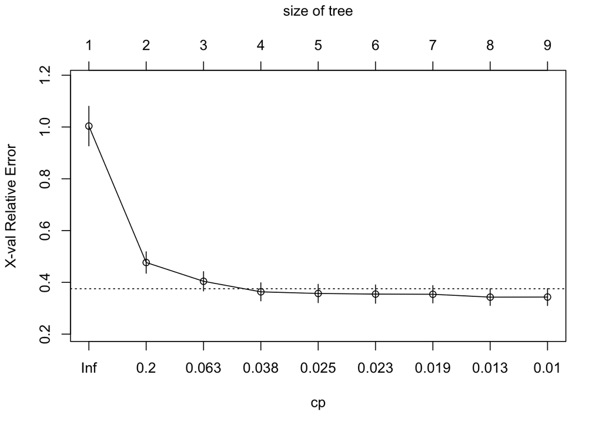

```r
plotcp(roz)
```

The current tree is too small. Let’s fit a bigger tree (i.e., fit a tree with a smaller CP value), and then do the pruning.

```r
roze = rpart(O3 ~ .,ozone, cp=0.001)
printcp(roze)
```

```
##
## Regression tree:
## rpart(formula = O3 ~ ., data = ozone, cp = 0.001)
##
## Variables actually used in tree construction:
## [1] doy      dpg      humidity ibh      ibt      temp     vh       vis
##
## Root node error: 21115/330 = 63.986
##
## n= 330
##
##           CP nsplit rel error  xerror     xstd
## 1  0.5456993      0   1.00000 1.00498 0.076794
## 2  0.0736591      1   0.45430 0.48780 0.042571
## 3  0.0535415      2   0.38064 0.42004 0.038678
## 4  0.0267557      3   0.32710 0.37515 0.035979
## 5  0.0232760      4   0.30034 0.38804 0.037594
## 6  0.0231021      5   0.27707 0.38021 0.037052
## 7  0.0153249      6   0.25397 0.36620 0.036409
## 8  0.0109137      7   0.23864 0.36552 0.037523
## 9  0.0070746      8   0.22773 0.35740 0.036794
## 10 0.0059918      9   0.22065 0.36352 0.037211
## 11 0.0059317     10   0.21466 0.37341 0.038773
## 12 0.0049709     12   0.20280 0.37136 0.039015
## 13 0.0047996     15   0.18789 0.37316 0.039028
## 14 0.0044712     16   0.18309 0.37634 0.039295
## 15 0.0031921     17   0.17861 0.37315 0.040055
## 16 0.0022152     19   0.17223 0.38181 0.040085
## 17 0.0020733     20   0.17002 0.37950 0.040006
## 18 0.0020297     22   0.16587 0.37914 0.040005
## 19 0.0014432     23   0.16384 0.37585 0.040050
## 20 0.0011322     24   0.16240 0.37457 0.040018
## 21 0.0011035     25   0.16126 0.37379 0.040033
## 22 0.0010000     26   0.16016 0.37319 0.040040
```

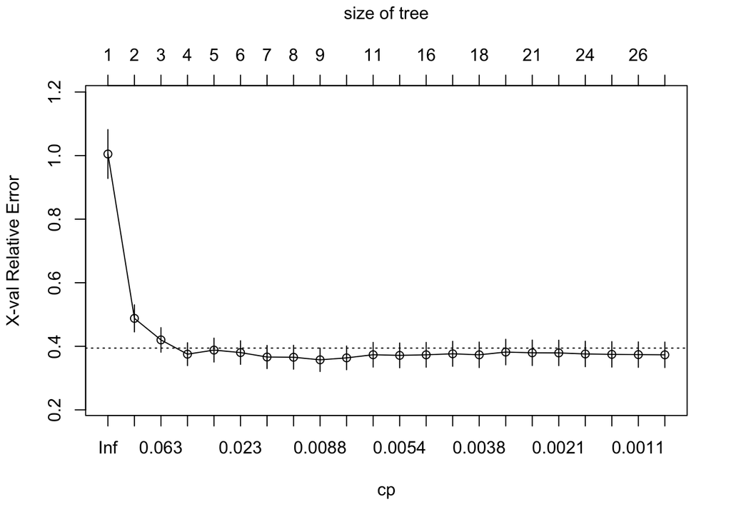

```r
plotcp(roze)
```

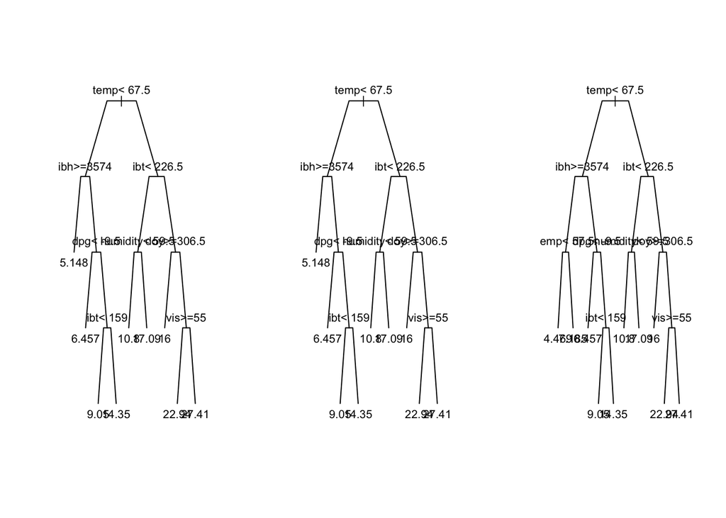

```r
tmp1=rpart(O3~., ozone, cp=0.01)
tmp2=rpart(O3~., ozone, cp=0.008)
tmp3=rpart(O3~., ozone, cp=0.007)
par(mfrow=c(1,3))
plot(tmp1,compress=T,uniform=T,branch=0.4,margin=.10)
text(tmp1)
plot(tmp2,compress=T,uniform=T,branch=0.4,margin=.10)
text(tmp2)
plot(tmp3,compress=T,uniform=T,branch=0.4,margin=.10)
text(tmp3)
```

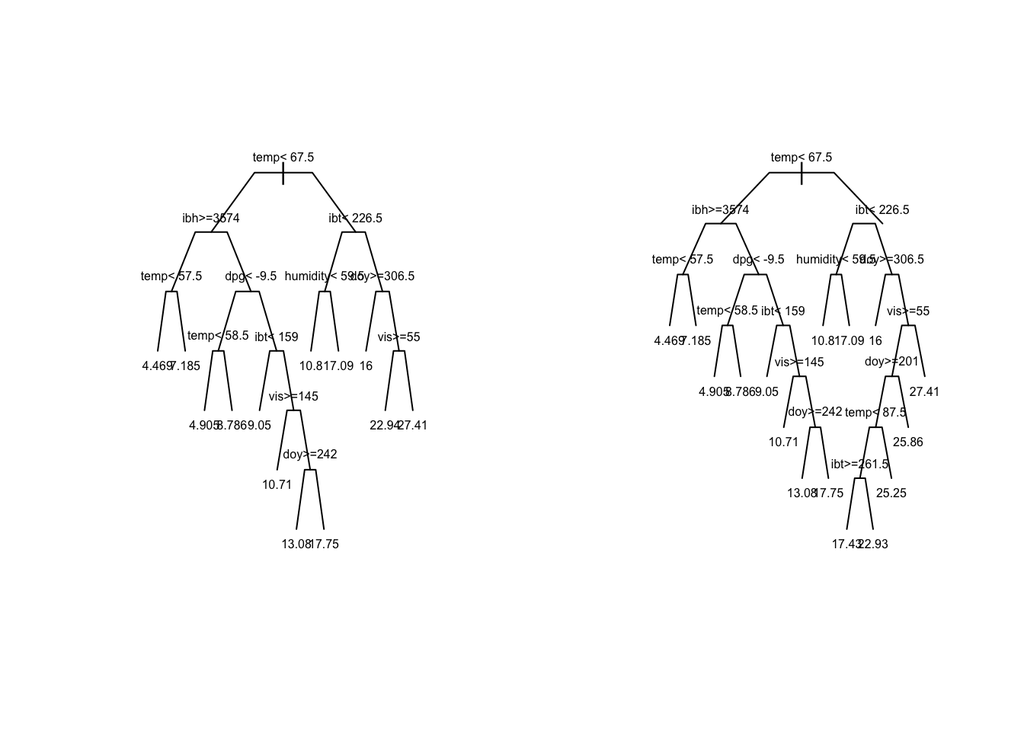

```r
tmp1=rpart(O3~., ozone, cp=0.0055)
tmp2=rpart(O3~., ozone, cp=0.0049)
par(mfrow=c(1,2))
plot(tmp1,compress=T,uniform=T,branch=0.4,margin=.10)
text(tmp1, cex=0.5)
plot(tmp2,compress=T,uniform=T,branch=0.4,margin=.10)
text(tmp2, cex=0.5)
```

However, we still don’t know what the optimal choice of CP is. The `cptable` gives us all candidate tree sizes. For each tree size, we compute the corresponding CV error, and then pick the subtree with the smallest CV errors. When rpart grows a tree it performs 10-fold cross validation on the data. There are usually two approaches to determining the optimal tree size:

- **size.min**: Pick the optimal tree size which has the smallest CV error.
- **size.1se**: Pick the smallest tree size whose CV error is within 1se (one-standard-error) of the smallest CV error.

Sometimes, these two approaches would give the same result, but sometimes they may not. For this particular example, from the CV error plot (produced by `plotcp`), we can see that the CV error first dropped dramatically when the tree size increases, and then became stabilized at roughly the same value for a wide range of tree sizes.

The size.1se approach may work better here: any tree, whose CV error is within one-standard error of the smallest CV error, would be a good choice, so we pick the smallest tree among them. The red line in the CV error plot marks the smallest CV error plus its one-standard-error, so we should just pick the smallest tree among all trees below the red line.

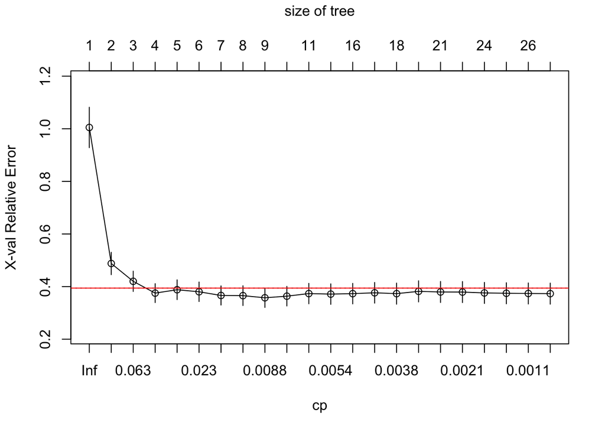

```r
myCPtable = roze$cptable
id.min = which.min(myCPtable[,'xerror'])
my1se.err = myCPtable[id.min,'xerror'] + myCPtable[id.min, 'xstd']
plotcp(roze)
abline(h=my1se.err, col="red")
```

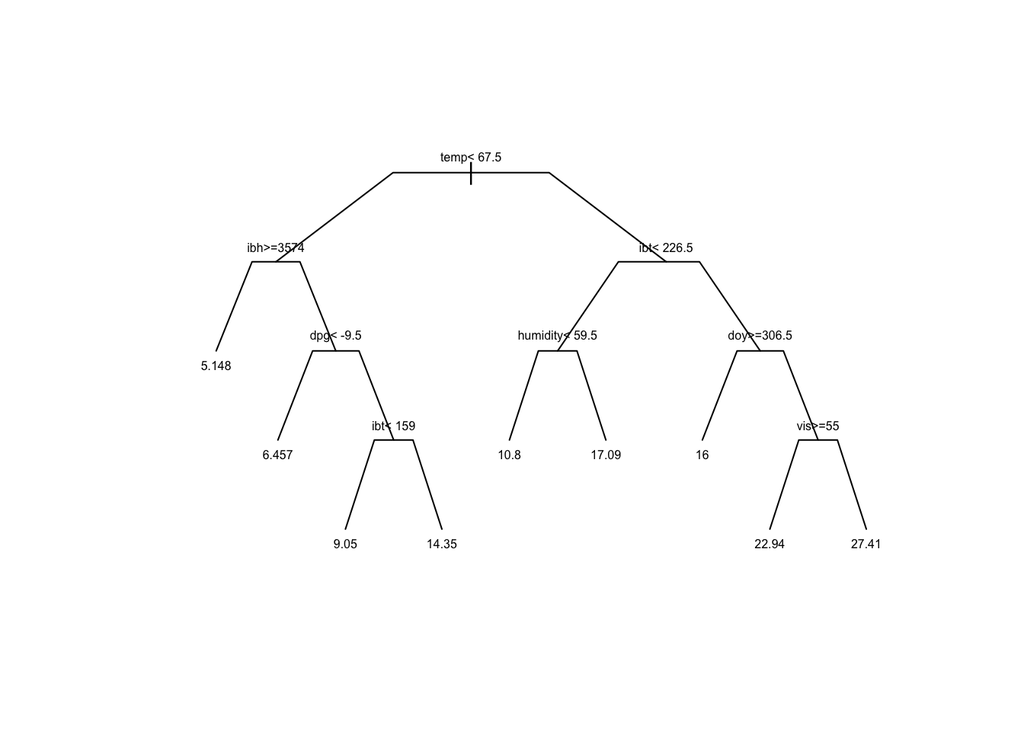

```r
# the red line should cover the original dashed line
# The size.min approach: pick the tree size with the smallest CV error.
# this can be done by pruning your tree using a CP value between myCPtable[id.min, 'CP'] and  myCPtable[id.min-1, 'CP']
# Of course, you need to modify the code if id.min =1.

CP.min = (myCPtable[id.min, 'CP'] + myCPtable[(id.min-1), 'CP'])/2
tree.min = prune.rpart(roze, CP.min)
plot(tree.min,compress=T,uniform=T,branch=0.4,margin=.10)
text(tree.min,cex=0.5)
```

```r
# The size.1se approach: pick the smallest tree below the red line
id.1se = min(which(myCPtable[,'xerror'] < my1se.err))
CP.1se = (myCPtable[id.1se, 'CP'] + myCPtable[(id.1se-1), 'CP'])/2
CP.1se
```

```
## [1] 0.04014864
```

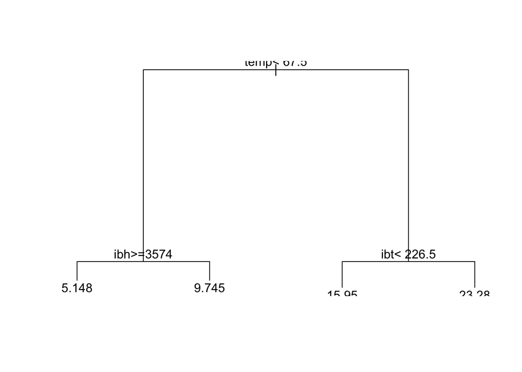

```r
tree.1se = prune.rpart(roze, CP.1se)
plot(tree.1se)
text(tree.1se)
```

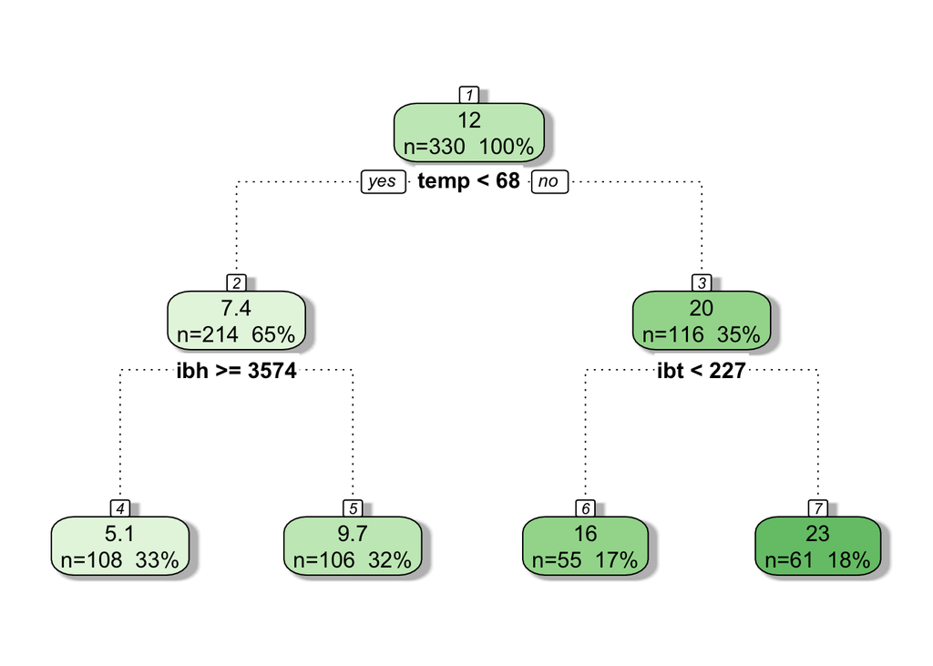

```r
# fancy plotting
library(rattle)
library(rpart.plot)
library(RColorBrewer)

# plot mytree
fancyRpartPlot(tree.1se, caption = NULL)
```

## Random Forests

```r
library(randomForest)
?randomForest
rfModel = randomForest(O3~., data = ozone)
```

Items returned by randomForest

- `ntree`: Number of trees in the forest, default = 500.
- `mtry`: at each split (of any tree), only `mtry` random chosen predictors are used as candidate predictors, default = 3.
- `oob.times`: oob = out of bag; for each tree, we draw a random sample (with replacement) of the data from a bag, and `oob.times` stands for the number of times a particular sample is *not selected* into the training set.

```r
names(rfModel)
```

```
##  [1] "call"            "type"            "predicted"       "mse"
##  [5] "rsq"             "oob.times"       "importance"      "importanceSD"
##  [9] "localImportance" "proximity"       "ntree"           "mtry"
## [13] "forest"          "coefs"           "y"               "test"
## [17] "inbag"           "terms"
```

```r
rfModel$ntree  # number of tress in the forest
```

```
## [1] 500
```

```r
rfModel$mtry
```

```
## [1] 3
```

How to extract yhat of the training data?

For regression, suppose the output is stored in `lmout`, then we can use 1) lmout$fitted; or 2) predict(lmout, newdata=trainingdata), and the two vectors should be the same.

For randomForest, however, the two approaches return different results. Why?

```r
yhat = predict(rfModel, newdata=ozone)
sum((ozone$O3 - yhat)^2)
```

```
## [1] 1005.801
```

```r
# which is different from rfModel$predicted.
sum((ozone$O3- rfModel$predicted)^2)
```

```
## [1] 5236.658
```

How is rfModel$predicted computed?

```r
length(rfModel$oob.times)
```

```
## [1] 330
```

```r
rfModel$oob.times[1:5]
```

```
## [1] 162 184 196 175 202
```

```r
length(rfModel$predicted)
```

```
## [1] 330
```

```r
rfModel$predicted[1:5]
```

```
##        1        2        3        4        5
## 5.407716 6.245199 9.684864 8.344667 5.288201
```

```r
# Then rfModel$predicted[1] is the average prediction of the 1st sample from the rfModel$oob.times[1] trees. So sum((ozone$O3- rfModel$predicted)^2) is more like a test error,  and sum((ozone$O3 - predict(rfModel, newdata=ozone) )^2) is like a training error, which is smaller.
```